# CPS85 Lab

Sep. 8, 2015

## Instructions

**Important:** Make sure you delete this entire section before you submit your file to RPubs!

In your groups, tackle the `CPS85` dataset within the `mosaicData` package. You may want to type `?CPS85` and `head(CPS85)` to get a glimpse at what this dataset contains. Next, start exploring the dataset using plots, tables, and other numeric summaries. Select 3 favorite plots and tell a story (in writing) about each of them. Extra brownie points if you can weave the 3 plots together into one cohesive story. You should include at least 1 univariate and 1 bivariate plot.

## PLOT 1

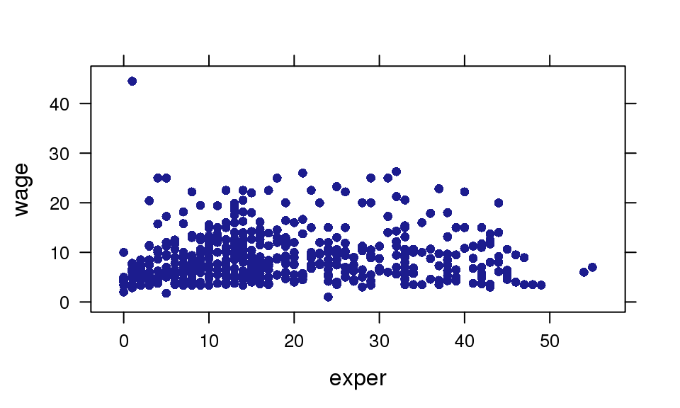

```r
xyplot(wage~exper, data = CPS85)
```

Difficult to see trends, although there is more clustering in the lower number of years in expertise. Expertise does not seem to have a clear correlation with wage.

## PLOT 2

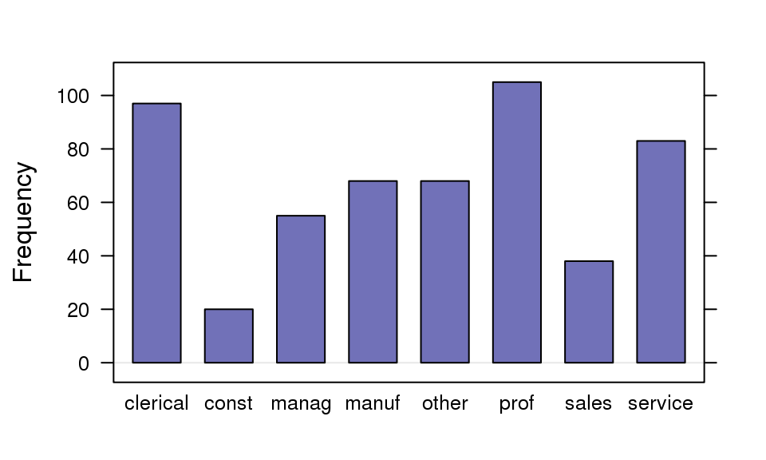

```r
bargraph(~sector, data=CPS85)
```

Displays frequency of data organized by sector. ‘Prof’ had the highest frequency (over 100) and ‘Construction’ had the lowest (around 20).

## PLOT 3

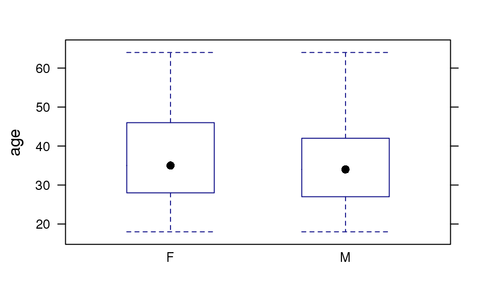

```r
bwplot(age~sex, data=CPS85)
```